# (Exploration of Bay Wheels's Trip Data)

## Investigation Overview

For this investigation I used "Ford GoBike System Data", I looked at bike hiring times and stations longitudes and latitudes to reveal their effect on the station hiring activity (How many bikes it hires).

## Dataset Overview

This data set includes information about individual rides made in a bike-sharing system covering the greater San Francisco Bay area for year 2019. The data has information of 2,506,983 rides and 334 stations. This information includes: start date and time, start station, end station, ride duration, longitudes and latitudes of start and end stations. Start and dnd stations are one set of stations. 433,555 data points (and 20 stations) were removed from the investigation due to inconsistencies or missing information.

## Distribution of Station Hiring Activity

The distribution of station hiring activity covers large scale of values. Plotted on a logarithmic scale, the distribution takes on a multimodal shape. The highest peaks are between ~ 2000 and 10000.

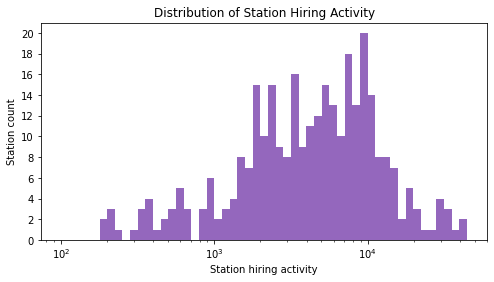

## Time Series of Weekly Hiring Activity

- There is a major decline in bike hiring after April 15th (Week 15 in the figure below).  
  *15/04/2019 — Citi Bike Pulls New Electric Bikes Off Streets, Citing Safety Concerns. The pedal-assist bikes operated by Lyft-owned companies in New York City, San Francisco and Washington were removed based on concerns over the brakes.* [NY Times](https://www.nytimes.com/2019/04/15/nyregion/citi-bike-electric.html)
- It seems that a lot of electric bikes fans in Bay area didn't hire bikes after that date.
- Before April 15th there was a clear inceasing trend which stopped after this date.
- The curve has noise before April 15th much more than after this date.
- Flipped spikes are due holidays such as 4th of july, 7th of july, Labor day, Thanks giving, Christmas, etc.

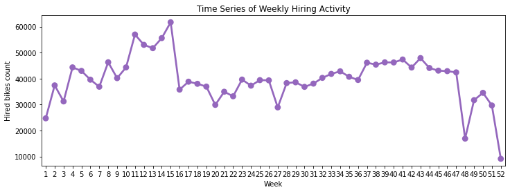

## Hiring activity vs. Day of week

- Working days have much more hiring activity than weekend.
- Interestingly, Tuesdays, Wendesdays and Thursdays have more hired bikes than Mandays and Fridays.
- Wendesdays have less hiring than Tuesdays and Thursdays

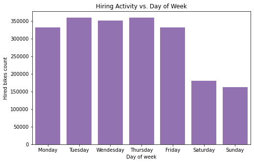

## Distribution of Hourly Hiring Activity

The distribution is bimodal as expected, with rush hours located at morning (7am, 8am, and 9am) and evening (4pm, 5pm, and 6pm).

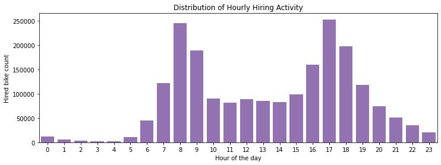

## Station categories

I splitted stations into four categories based on their hiring activity quartiles:

Category A: Stations that hired less than 2031 bikes.  
Category B: Stations that hired more than 2031 bikes and less than 4543 bikes.  
Category C: Stations that hired more than 4543 bikes and less than 8859 bikes.  
Category D: Stations that hired more than 8859 bikes.

## Station Category by Day of Week and Hiring Activity

The busier the stations are, the larger the difference between hired bikes count in weekdays and in weekends.

[figure not shown]

## Time series of weekly hired bikes by station category

Flipped spikes in the curve of category D stations have large magnitudes while those of the other categories are merely noticed. As mentioned before flipped spikes are due holidays. Therefore, category D stations are affected by holidays much more than other categories.

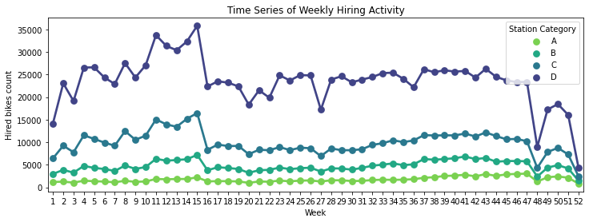

## Hourly Hiring Activity by Station Category

Category D stations hires much more bikes in evening rush hours than morning rush hours while it is the opposite for category C stations.

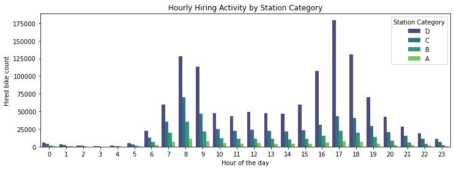

## Station Location by Station Category

- The stations are geo-seperated into two groups, East Bay and West Bay. East Bay is at the North East and West Bay is at the South West and they are seperated by water.
- West bay has larger number of stations than the East bay.
- Most of the busiest stations (categories D and C) are in West Bay area while East Bay has mostly less busier stations (categories A and B).
- In the West Bay area, Category D stations are concentrated at North East (the busiest region of the Bay) by and near the see.
- As you move inside the land towards South West, category C stations dominate.
- Category B are scaterred here and there withen these two regions while category A stations mostly reside outside the busy regions.

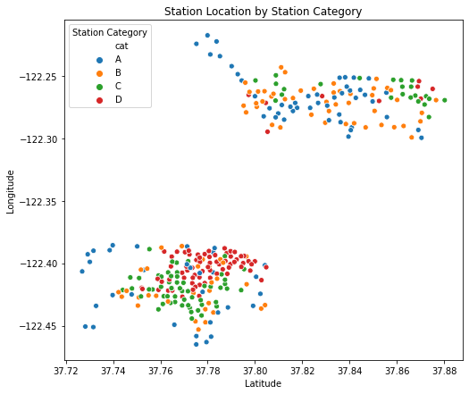

## Station Category by Ride Duration Mean and Day of Week

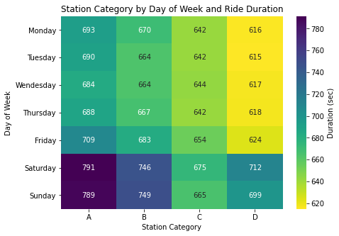